# Comparing Climate Data

November 26, 2018

## WorldClim vs. NEX-DCP30

### WorldClim (UC-Berkely)

- Monthly temperature and precipitation + 19 bioclimatic metrics
- 30 arc-second (~800m) resolution
- 'Current' interpolated from actual station data, averaged over 1960-1990 *more or less*
  - interpolated using ANUSPLIN algorithm
- 'Future' includes **2050** (2041-2060) and **2070** (2061-2080), for 17 GCMs & 4 RCPs
  - downscaled and 'calibrated' using the Current dataset
- Version 1 (2005), includes 'Current' and 'Future'
- Version 2 (2016) meant to correct issues with v.1 *But is for Current (1970-2000) only*

### NEX-DCP30 (NASA)

- Modeled (not from station data), monthly temperature and precipitation
- 30 arc-second (~800m) resolution
- Bias Corrected Spatially Downscaled method, 33 GCMs (or ensemble) & 4 RCPs
- 'Current' spans 1950 - 2005, all years individually available
- 'Future' spans 2006 - 2099, all years individually available
- From 2013
- Michelle can create any combination of metrics from any timeperiod or model(s)

## Visualizing Differences

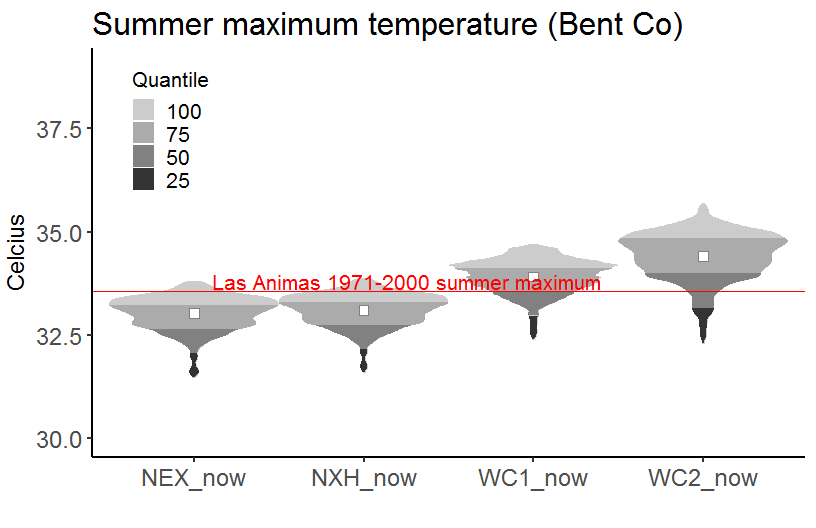

- NEX_now: NEX-DCP30 ens. average 1970-2000
- NXH_now: NEX-DCP30 MIROC-ESM.RCP8.5 1970-2000
- WC1_now: WorldClim v.1 1960-1990
- WC2_now: WorldClim v.2 1970-2000
- Las Animas station data from W. Regional Climate Center (wrcc.dri.edu)

## Visualizing Differences

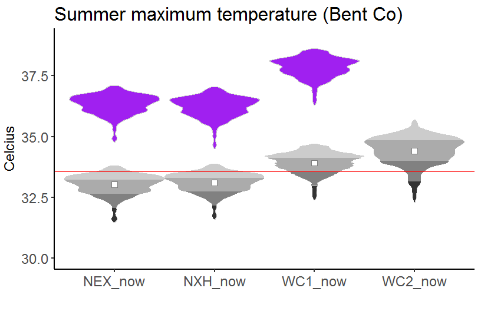

- Future for WorldClim v.1 = 2041-2060
- Future for both NEX-DCP30 examples = 2035-2065

## Visualizing Differences - A different county

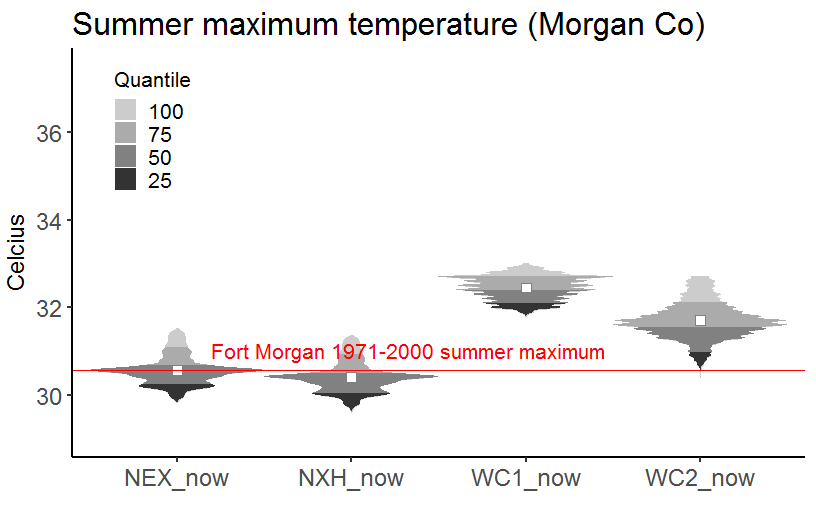

## Visualizing Differences - A different county

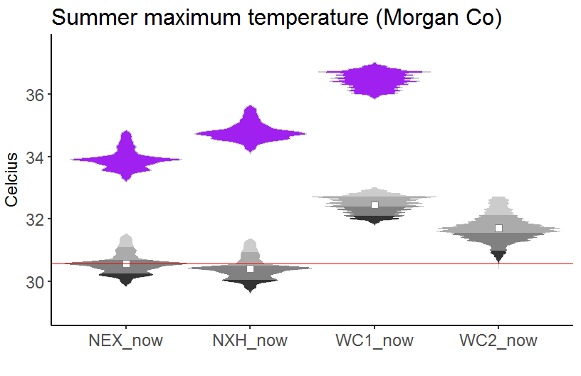

## The Bioclimatic Variables

- BIO1 = Annual Mean Temperature
- BIO2 = Mean Diurnal Range (Mean of monthly (max temp - min temp))
- BIO3 = Isothermality (BIO2/BIO7) (* 100)
- BIO4 = Temperature Seasonality (standard deviation *100)
- BIO5 = Max Temperature of Warmest Month
- BIO6 = Min Temperature of Coldest Month
- BIO7 = Temperature Annual Range (BIO5-BIO6)
- BIO8 = Mean Temperature of Wettest Quarter
- BIO9 = Mean Temperature of Driest Quarter
- BIO10 = Mean Temperature of Warmest Quarter
- BIO11 = Mean Temperature of Coldest Quarter
- BIO12 = Annual Precipitation
- BIO13 = Precipitation of Wettest Month
- BIO14 = Precipitation of Driest Month
- BIO15 = Precipitation Seasonality (Coefficient of Variation)
- BIO16 = Precipitation of Wettest Quarter
- BIO17 = Precipitation of Driest Quarter
- BIO18 = Precipitation of Warmest Quarter
- BIO19 = Precipitation of Coldest Quarter